# Kaggle Titanic

# Step - 3 : Analyse the Data

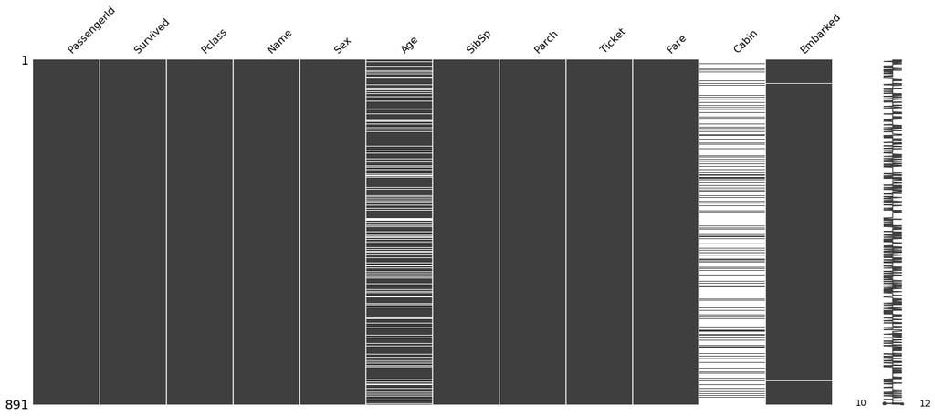

```python
ms.matrix(data)
```

```python
data.info()
```

```
<class 'pandas.core.frame.DataFrame'>
RangeIndex: 891 entries, 0 to 890
Data columns (total 12 columns):
PassengerId    891 non-null int64
Survived       891 non-null int64
Pclass         891 non-null int64
Name           891 non-null object
Sex            891 non-null object
Age            714 non-null float64
SibSp          891 non-null int64
Parch          891 non-null int64
Ticket         891 non-null object
Fare           891 non-null float64
Cabin          204 non-null object
Embarked       889 non-null object
dtypes: float64(2), int64(5), object(5)
memory usage: 83.6+ KB
```

We can observe that there are missing values in 'Age', 'Cabin' and 'Embarked'. Let's continue.

```python
data.info()
```

```
<class 'pandas.core.frame.DataFrame'>
RangeIndex: 891 entries, 0 to 890
Data columns (total 12 columns):
PassengerId    891 non-null int64
Survived       891 non-null int64
Pclass         891 non-null int64
Name           891 non-null object
Sex            891 non-null object
Age            714 non-null float64
SibSp          891 non-null int64
Parch          891 non-null int64
Ticket         891 non-null object
Fare           891 non-null float64
Cabin          204 non-null object
Embarked       889 non-null object
dtypes: float64(2), int64(5), object(5)
memory usage: 83.6+ KB
```

Visualization of data with Seaborn

[output not shown]

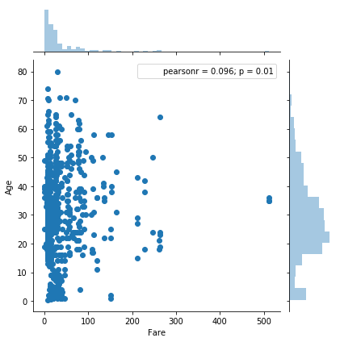

```python
sns.jointplot(x='Fare',y='Age',data=data)
```

[output not shown]

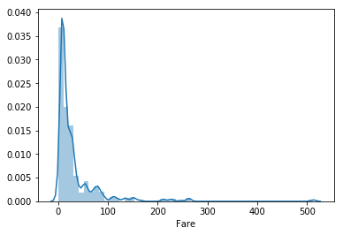

```python
sns.distplot(data['Fare'])
```

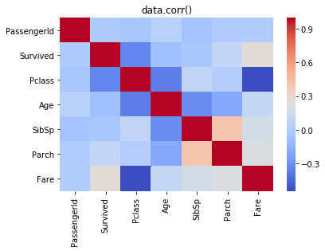

```python
sns.heatmap(data.corr(),cmap='coolwarm')
plt.title('data.corr()')
```

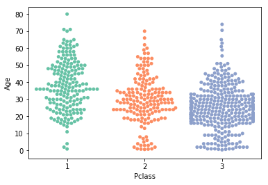

```python
sns.swarmplot
sns.swarmplot(x='Pclass',y='Age',data=data,palette='Set2')
```

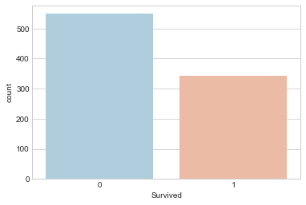

```python
sns.set_style('whitegrid')
sns.countplot(x='Survived',data=data,palette='RdBu_r')
```

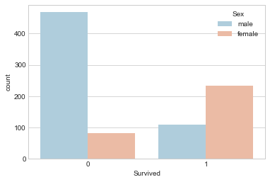

```python
sns.set_style('whitegrid')
sns.countplot(x='Survived',hue='Sex',data=data,palette='RdBu_r')
```

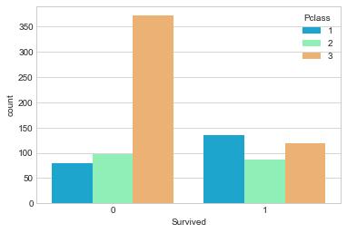

```python
sns.set_style('whitegrid')
sns.countplot(x='Survived',hue='Pclass',data = data,palette='rainbow')
```

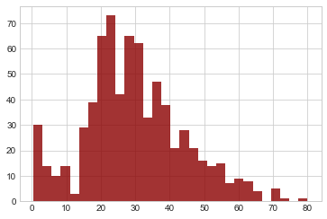

```python
data['Age'].hist(bins = 30, color = 'darkred', alpha = 0.8)
```

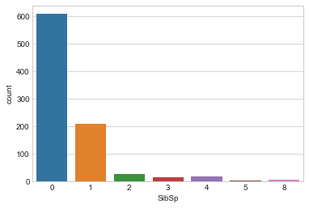

```python
sns.countplot(x = 'SibSp', data = data)
```

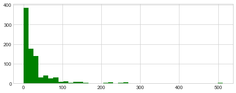

```python
data['Fare'].hist(color = 'green', bins = 40, figsize = (8,3))
```

#### What do you observe from the above charts?

# Step - 4 : Feature Engineering

## Feature Engineering

We want to fill the missing values of the age in the dataset with the average age value for each of the classes. This is called data imputation.

```python
data.info()
```

```
<class 'pandas.core.frame.DataFrame'>
RangeIndex: 891 entries, 0 to 890
Data columns (total 12 columns):
PassengerId    891 non-null int64
Survived       891 non-null int64
Pclass         891 non-null int64
Name           891 non-null object
Sex            891 non-null object
Age            714 non-null float64
SibSp          891 non-null int64
Parch          891 non-null int64
Ticket         891 non-null object
Fare           891 non-null float64
Cabin          204 non-null object
Embarked       889 non-null object
dtypes: float64(2), int64(5), object(5)
memory usage: 83.6+ KB
```

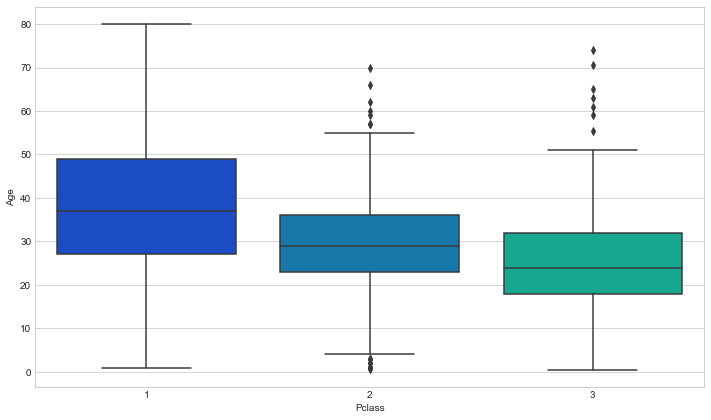

```python
plt.figure(figsize=(12, 7))
sns.boxplot(x='Pclass',y='Age',data=data,palette='winter')
```

```python
data['Cabin'].value_counts()
```

```
C23 C25 C27        4
G6                 4
B96 B98            4
F2                 3
D                  3
E101               3
F33                3
C22 C26            3
C92                2
D20                2
C2                 2
D26                2
E24                2
B35                2
C65                2
D36                2
B28                2
F G73              2
C93                2
C125               2
C52                2
B57 B59 B63 B66    2
D35                2
B51 B53 B55        2
E67                2
B20                2
B22                2
C126               2
E121               2
D17                2
                  ..
E10                1
B94                1
A34                1
A31                1
C101               1
B80                1
A32                1
C103               1
C32                1
C49                1
B30                1
A20                1
C99                1
F38                1
C85                1
B79                1
B78                1
F G63              1
A6                 1
B73                1
E68                1
E17                1
B19                1
B86                1
C50                1
C104               1
A16                1
B4                 1
C95                1
D47                1
Name: Cabin, Length: 147, dtype: int64
```

The average age for each of the classes are estimated to be as follows:

- For **Class 1** - The median age is 37
- For **Class 2** - The median age is 29
- For **Class 3** - The median age is 24

Let's impute these values into the age column.

```python
def impute_age(cols):
    Age = cols[0]
    Pclass = cols[1]

    if pd.isnull(Age):
        # Class-1
        if Pclass == 1:
            return 37
        # Class-2
        elif Pclass == 2:
            return 29
        # Class-3
        else:
            return 24

    else:
        return Age
```

Applying the function.

```python
data['Age'] = data[['Age','Pclass']].apply(impute_age,axis=1)
```

Now let's visualize the missing values.

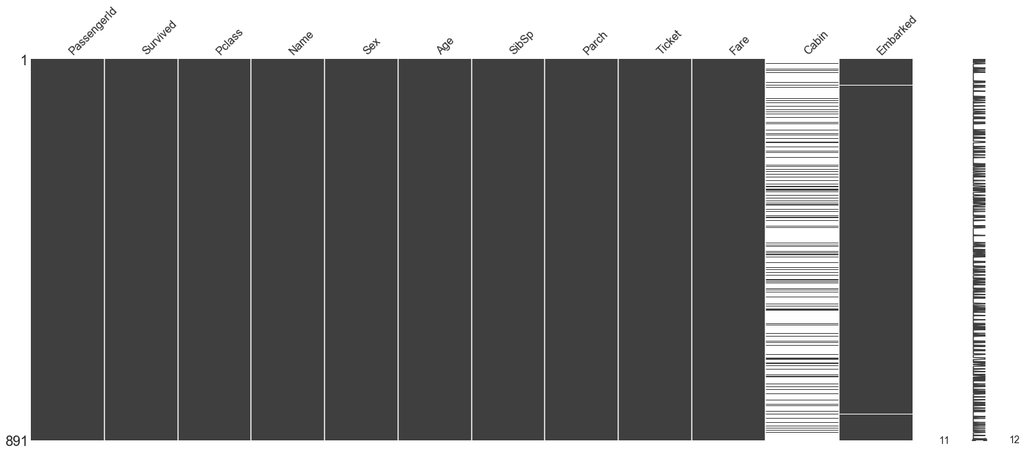

```python
ms.matrix(data)
```

The Age column is imputed sucessfully.

```python
data.drop('Cabin', axis = 1,inplace=True)
```

```python
data.head()
```

|  | PassengerId | Survived | Pclass | Name | Sex | Age | SibSp | Parch | Ticket | Fare | Embarked |
| --- | --- | --- | --- | --- | --- | --- | --- | --- | --- | --- | --- |
| 0 | 1 | 0 | 3 | Braund, Mr. Owen Harris | male | 22.0 | 1 | 0 | A/5 21171 | 7.2500 | S |
| 1 | 2 | 1 | 1 | Cumings, Mrs. John Bradley (Florence Briggs Th... | female | 38.0 | 1 | 0 | PC 17599 | 71.2833 | C |
| 2 | 3 | 1 | 3 | Heikkinen, Miss. Laina | female | 26.0 | 0 | 0 | STON/O2. 3101282 | 7.9250 | S |
| 3 | 4 | 1 | 1 | Futrelle, Mrs. Jacques Heath (Lily May Peel) | female | 35.0 | 1 | 0 | 113803 | 53.1000 | S |
| 4 | 5 | 0 | 3 | Allen, Mr. William Henry | male | 35.0 | 0 | 0 | 373450 | 8.0500 | S |

```python
data.dropna(inplace = True)
```

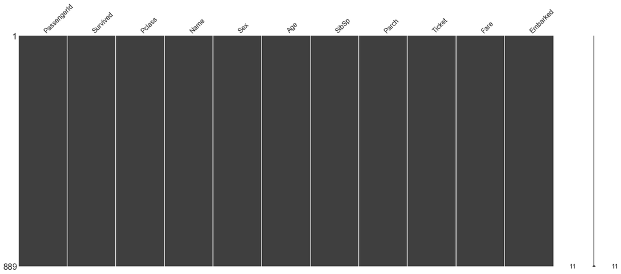

```python
ms.matrix(data)
```

```python
data.info()
```

```
<class 'pandas.core.frame.DataFrame'>
Int64Index: 889 entries, 0 to 890
Data columns (total 11 columns):
PassengerId    889 non-null int64
Survived       889 non-null int64
Pclass         889 non-null int64
Name           889 non-null object
Sex            889 non-null object
Age            889 non-null float64
SibSp          889 non-null int64
Parch          889 non-null int64
Ticket         889 non-null object
Fare           889 non-null float64
Embarked       889 non-null object
dtypes: float64(2), int64(5), object(4)
memory usage: 83.3+ KB
```

## Converting Categorical Features

We'll need to convert categorical features to dummy variables using pandas! Otherwise our machine learning algorithm won't be able to directly take in those features as inputs.

```python
data['Embarked'].value_counts()
```

```
S    644
C    168
Q     77
Name: Embarked, dtype: int64
```

```python
sex = pd.get_dummies(data['Sex'],drop_first=1)
embark = pd.get_dummies(data['Embarked'],drop_first=1)
sex.head()
```

|  | male |
| --- | --- |
| 0 | 1 |
| 1 | 0 |
| 2 | 0 |
| 3 | 0 |
| 4 | 1 |

```python
embark.head()
```

|  | Q | S |
| --- | --- | --- |
| 0 | 0 | 1 |
| 1 | 0 | 0 |
| 2 | 0 | 1 |
| 3 | 0 | 1 |
| 4 | 0 | 1 |

```python
old_data = data.copy()
data.drop(['Sex','Embarked','Name','Ticket'],axis=1,inplace=True)
data.head()
```

|  | PassengerId | Survived | Pclass | Age | SibSp | Parch | Fare |
| --- | --- | --- | --- | --- | --- | --- | --- |
| 0 | 1 | 0 | 3 | 22.0 | 1 | 0 | 7.2500 |
| 1 | 2 | 1 | 1 | 38.0 | 1 | 0 | 71.2833 |
| 2 | 3 | 1 | 3 | 26.0 | 0 | 0 | 7.9250 |
| 3 | 4 | 1 | 1 | 35.0 | 1 | 0 | 53.1000 |
| 4 | 5 | 0 | 3 | 35.0 | 0 | 0 | 8.0500 |

```python
old_data.info()
```

```
<class 'pandas.core.frame.DataFrame'>
Int64Index: 889 entries, 0 to 890
Data columns (total 11 columns):
PassengerId    889 non-null int64
Survived       889 non-null int64
Pclass         889 non-null int64
Name           889 non-null object
Sex            889 non-null object
Age            889 non-null float64
SibSp          889 non-null int64
Parch          889 non-null int64
Ticket         889 non-null object
Fare           889 non-null float64
Embarked       889 non-null object
dtypes: float64(2), int64(5), object(4)
memory usage: 83.3+ KB
```

```python
data = pd.concat([data,sex,embark],axis=1)
```

```python
data.head()
```

|  | PassengerId | Survived | Pclass | Age | SibSp | Parch | Fare | male | Q | S |
| --- | --- | --- | --- | --- | --- | --- | --- | --- | --- | --- |
| 0 | 1 | 0 | 3 | 22.0 | 1 | 0 | 7.2500 | 1 | 0 | 1 |
| 1 | 2 | 1 | 1 | 38.0 | 1 | 0 | 71.2833 | 0 | 0 | 0 |
| 2 | 3 | 1 | 3 | 26.0 | 0 | 0 | 7.9250 | 0 | 0 | 1 |
| 3 | 4 | 1 | 1 | 35.0 | 1 | 0 | 53.1000 | 0 | 0 | 1 |
| 4 | 5 | 0 | 3 | 35.0 | 0 | 0 | 8.0500 | 1 | 0 | 1 |

```python
data.info()
```

```
<class 'pandas.core.frame.DataFrame'>
Int64Index: 889 entries, 0 to 890
Data columns (total 10 columns):
PassengerId    889 non-null int64
Survived       889 non-null int64
Pclass         889 non-null int64
Age            889 non-null float64
SibSp          889 non-null int64
Parch          889 non-null int64
Fare           889 non-null float64
male           889 non-null uint8
Q              889 non-null uint8
S              889 non-null uint8
dtypes: float64(2), int64(5), uint8(3)
memory usage: 58.2 KB
```

```python
data.describe()
```

|  | PassengerId | Survived | Pclass | Age | SibSp | Parch | Fare | male | Q | S |
| --- | --- | --- | --- | --- | --- | --- | --- | --- | --- | --- |
| count | 889.000000 | 889.000000 | 889.000000 | 889.000000 | 889.000000 | 889.000000 | 889.000000 | 889.000000 | 889.000000 | 889.000000 |
| mean | 446.000000 | 0.382452 | 2.311586 | 29.019314 | 0.524184 | 0.382452 | 32.096681 | 0.649044 | 0.086614 | 0.724409 |
| std | 256.998173 | 0.486260 | 0.834700 | 13.209814 | 1.103705 | 0.806761 | 49.697504 | 0.477538 | 0.281427 | 0.447063 |
| min | 1.000000 | 0.000000 | 1.000000 | 0.420000 | 0.000000 | 0.000000 | 0.000000 | 0.000000 | 0.000000 | 0.000000 |
| 25% | 224.000000 | 0.000000 | 2.000000 | 22.000000 | 0.000000 | 0.000000 | 7.895800 | 0.000000 | 0.000000 | 0.000000 |
| 50% | 446.000000 | 0.000000 | 3.000000 | 26.000000 | 0.000000 | 0.000000 | 14.454200 | 1.000000 | 0.000000 | 1.000000 |
| 75% | 668.000000 | 1.000000 | 3.000000 | 36.500000 | 1.000000 | 0.000000 | 31.000000 | 1.000000 | 0.000000 | 1.000000 |
| max | 891.000000 | 1.000000 | 3.000000 | 80.000000 | 8.000000 | 6.000000 | 512.329200 | 1.000000 | 1.000000 | 1.000000 |

# Step - 5 : Model Selection

## Building a Logistic Regression model

```python
from sklearn.model_selection import train_test_split
```

```python
X_train, X_test, y_train, y_test = train_test_split(data.drop('Survived',axis=1),
                                                    data['Survived'], test_size=0.30,
                                                    random_state=101)
```

```python
len(y_test)
```

```
267
```

```python
267/889
```

```
0.30033745781777277
```

```python
from sklearn.linear_model import LogisticRegression

# Build the Model.
logmodel = LogisticRegression()
logmodel.fit(X_train,y_train)
```

```
LogisticRegression(C=1.0, class_weight=None, dual=False, fit_intercept=True,
          intercept_scaling=1, max_iter=100, multi_class='ovr', n_jobs=1,
          penalty='l2', random_state=None, solver='liblinear', tol=0.0001,
          verbose=0, warm_start=False)
```

```python
logmodel.coef_
```

```
array([[ 4.07960392e-04, -7.86365639e-01, -2.63397204e-02,
        -2.12110222e-01, -9.70464669e-02,  4.63352441e-03,
        -2.34157449e+00, -1.74569644e-02, -1.93377741e-01]])
```

```python
predict =  logmodel.predict(X_test)
predict[:5]
```

```
array([0, 0, 1, 1, 0], dtype=int64)
```

```python
y_test[:5]
```

```
511    0
613    0
615    1
337    1
718    0
Name: Survived, dtype: int64
```

Let's move on to evaluate our model.

# Step - 6 : Evaluation

## Evaluation

We can check precision, recall, f1 - score using classification report!

#### Confusion Matrix

```python
from sklearn.metrics import confusion_matrix, classification_report
```

## Confusion Matrix

```python
print(confusion_matrix(y_test, predict))
```

```
[[151  12]
 [ 36  68]]
```

#### Precision Score

The precision is the ratio tp / (tp + fp) where tp is the number of true positives and fp the number of false positives. The precision is intuitively the ability of the classifier not to label as positive a sample that is negative.

The best value is 1 and the worst value is 0.

```python
from sklearn.metrics import precision_score
```

```python
print(precision_score(y_test,predict))
```

```
0.85
```

#### Recall score

The recall is the ratio tp / (tp + fn) where tp is the number of true positives and fn the number of false negatives. The recall is intuitively the ability of the classifier to find all the positive samples.

The best value is 1 and the worst value is 0.

```python
from sklearn.metrics import recall_score
```

```python
print(recall_score(y_test,predict))
```

```
0.6538461538461539
```

#### f1_score

The F1 score can be interpreted as a weighted average of the precision and recall, where an F1 score reaches its best value at 1 and worst score at 0. The relative contribution of precision and recall to the F1 score are equal. The formula for the F1 score is: F1 = 2 * (precision * recall) / (precision + recall)

```python
from sklearn.metrics import f1_score
```

```python
print(f1_score(y_test,predict))
```

```
0.7391304347826088
```

To get all the above metrics at one go, use the following function:

```python
from sklearn.metrics import classification_report
```

```python
print(classification_report(y_test,predict))
```

```
             precision    recall  f1-score   support

          0       0.81      0.93      0.86       163
          1       0.85      0.65      0.74       104

avg / total       0.82      0.82      0.81       267
```

# Step - 7 : Predict on New Cases

## Prediction on Test Data From Kaggle

create an account on www.kaggle.com

```python
!wget https://www.dropbox.com/s/6hyaidkuyfsv45u/production.csv
prod_data=pd.read_csv('production.csv')
```

[output not shown]

[output not shown]

```python
prod_data.info()
```

[output not shown]

```python
prod_data.head()
```

[output not shown]

```python
ms.matrix(prod_data)
```

[output not shown]

### Data Cleaning

```python
prod_data['Age'] = prod_data[['Age','Pclass']].apply(impute_age,axis=1)
```

```python
ms.matrix(prod_data)
```

[output not shown]

```python
prod_data.drop('Cabin', axis = 1, inplace= True)
```

```python
ms.matrix(prod_data)
```

[output not shown]

```python
prod_data.fillna(prod_data['Fare'].mean(),inplace=True)
```

```python
prod_data.info()
```

[output not shown]

```python
ms.matrix(prod_data)
```

[output not shown]

```python
sex = pd.get_dummies(prod_data['Sex'], drop_first=True)
embark = pd.get_dummies(prod_data['Embarked'], drop_first=True)

prod_data.drop(['Sex','Embarked','Name','Ticket'],axis=1,inplace=True)

prod_data = pd.concat([prod_data,sex,embark],axis=1)
```

```python
prod_data.head()
```

[output not shown]

```python
predict1=logmodel.predict(prod_data)
```

```python
predict1
```

[output not shown]

```python
df1=pd.DataFrame(predict1,columns=['Survived'])
```

```python
df2=pd.DataFrame(prod_data['PassengerId'],columns=['PassengerId'])
```

```python
df2.head()
```

[output not shown]

```python
result = pd.concat([df2,df1],axis=1)
result.head()
```

[output not shown]

```python
result.to_csv('result.csv',index=False)
```

```python
from google.colab import files
files.download('result.csv')
```

```python
!ls -l
```

Submit the file to https://www.kaggle.com/c/titanic

```
                                                 THE END
```